# Frequentist Analysis of Gambling Warning: Roksy Choice Experiment

Philip Newall, Lukasz Walasek, Henrik Singmann, Elliot Ludvig

2022-03-08

# Setup

```r
library("afex")
library("emmeans")
library("tidyverse")
theme_set(theme_bw(base_size = 15) +
            theme(legend.position="bottom"))
library("binom")
library("parallel")
library("emmeans")
source("analysis_fun.R")
nc <- detectCores() # number of cores
cl <- makeCluster(rep("localhost", nc)) # make cluster
clusterEvalQ(cl, library("optimx"))
```

```r
din <- read_csv("data/Soccerwarnings1.csv",
                col_types = cols(
                  .default = col_double(),
                  gendertext = col_logical(),
                  comments = col_character(),
                  PROLIFIC_PID = col_character(),
                  ordercontrol = col_character(),
                  orderwarning = col_character()
                )) %>%
  mutate(newid = factor(1:nrow(.)))

dl <- din %>%
  select(newid, starts_with("control"), starts_with("warning")) %>%
  gather("condition", "response", -newid) %>%
  filter(!is.na(response)) %>%
  mutate(item = as.numeric(str_extract(condition, "\\d"))) %>%
  mutate(label = factor(str_remove(condition, "\\d"),
                            levels = c("warning", "control"))) %>%
  mutate(complexity = factor(case_when(
    item <= 3 ~ "low",
    item <= 6 ~ "medium",
    item <= 9 ~ "high",
    TRUE ~ NA_character_
  ), levels = c("low", "medium", "high")))
dl %>%
  group_by(newid) %>%
  summarise(check = mean(label == "control")) %>%
  {all(.$check %in% c(0, 1))} ## all newid in one condition only?
```

```
## [1] TRUE
```

Two (anonymized) IDs seem to have taken part in the experiment twice.

```r
ids <- table(din$PROLIFIC_PID)
ids[ ids > 1 ]
```

```
##
## 361cf24307b89e6ca5954f9fedd64fb0bdbdd8904055c34f0bb6479d513dc394
##                                                                2
## b96c613a6ceb9e343b259cbb69d0211527f3ac38cc3619908df1f80a50120b13
##                                                                2
```

We therefore exclude those participants from the data.

```r
ids_remove <- din %>%
  filter(PROLIFIC_PID %in% names(ids[ ids > 1 ])) %>%
  .$newid

dl <- dl %>%
  filter(!(newid %in% ids_remove))
```

# Demographics

```r
add_vars <- din %>%
  filter(!(newid %in% ids_remove)) %>%
  mutate(psg = rowSums(select(., starts_with("pgsi")))) %>%
  select(newid, gender, age, freq, psg) %>%
  mutate(gender = factor(gender, levels = 1:4,
                         labels = c("Male", "Female", "other", "no-answer")),
         age_z = get_z(age),
         freq_z = get_z(freq),
         psg_z = get_z(psg))
```

Gender distribution:

```r
any(!is.na(din$gendertext))
```

```
## [1] FALSE
```

```r
add_vars %>%
  group_by(gender) %>%
  tally() %>%
  mutate(p = n / sum(n))
```

```
## # A tibble: 3 x 3
##   gender     n       p
##   <fct>  <int>   <dbl>
## 1 Male     168 0.332
## 2 Female   337 0.666
## 3 <NA>       1 0.00198
```

Distribution of other covariates:

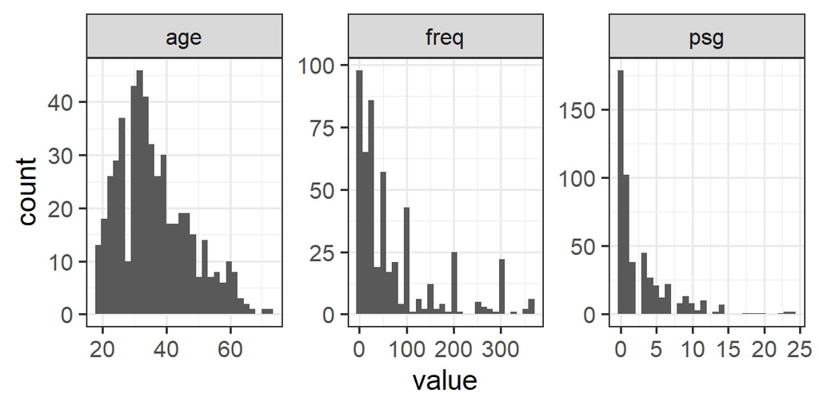

```r
add_vars %>%
  gather("variable", "value", psg, freq, age) %>%
  ggplot(aes(value)) +
  geom_histogram(bins = 30) +
  facet_wrap("variable", scales = "free")
```

```r
add_vars %>%
  select(psg, freq, age) %>%
  psych::describe()
```

```
##      vars   n  mean    sd median trimmed   mad min max range skew kurtosis   se
## psg     1 506  2.92  4.16    1.0    2.05  1.48   0  24    24 2.23     6.01 0.18
## freq    2 506 71.31 87.47   37.5   53.49 48.18   0 365   365 1.68     2.00 3.89
## age     3 506 36.12 11.15   34.0   35.24 10.38  18  72    54 0.68    -0.11 0.50
```

We can also inspect the inter-correlation among those:

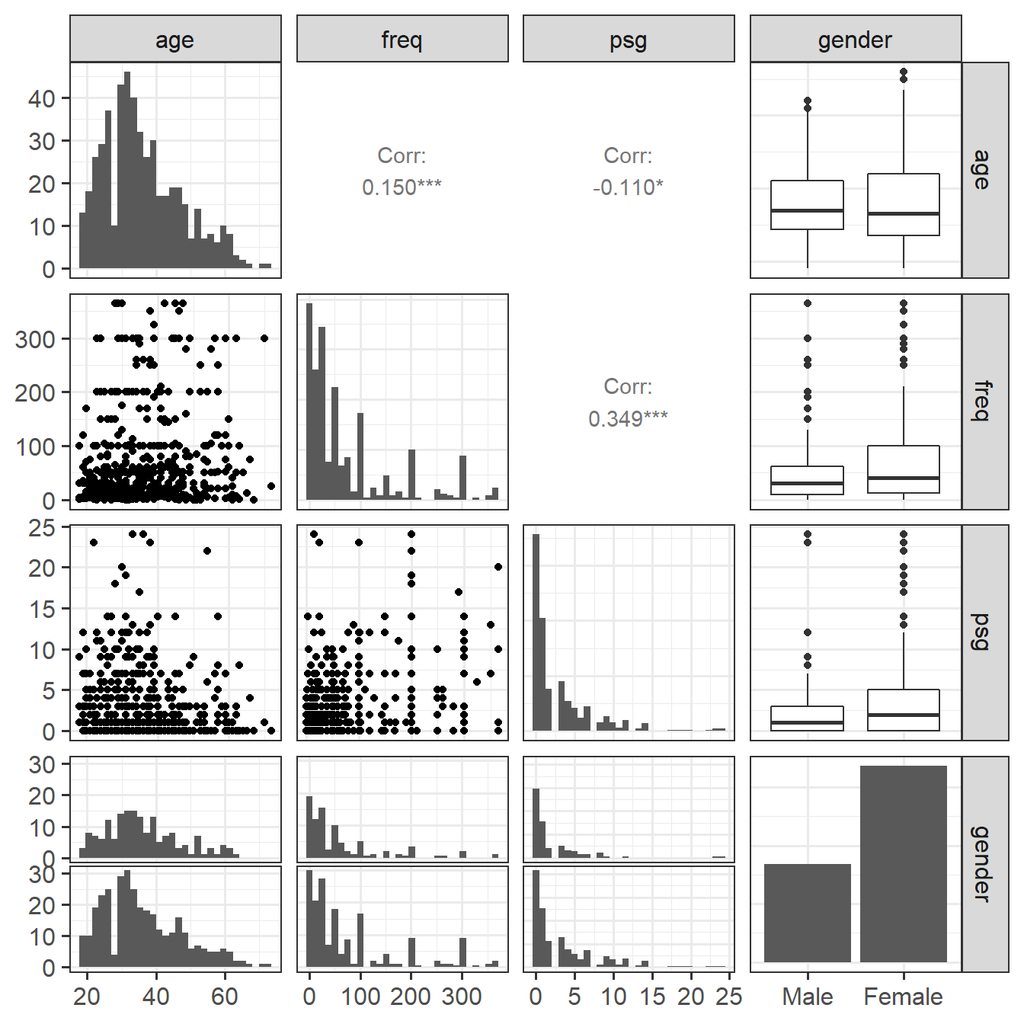

```r
add_vars %>%
  select(age, freq, psg, gender) %>%
  na.omit() %>%
  GGally::ggpairs(progress = FALSE, diag = list(continuous = "barDiag"))
```

# Descriptives

Overview of participants that decided to reject all bets:

```r
dl %>%
  group_by(newid, label) %>%
  summarise(average = mean(response)) %>%
  ungroup()  %>%
  summarise(
    n_no_gamble = sum(average == 0),
    prop_no_gamble = mean(average == 0)
  )
```

```
## # A tibble: 1 x 2
##   n_no_gamble prop_no_gamble
##         <int>          <dbl>
## 1          56          0.111
```

```r
dl %>%
  group_by(label) %>%
  summarise(c = list(binom.confint(sum(response), n = n()))) %>%
  unnest(c) %>%
  filter(method == "agresti-coull")
```

```
## # A tibble: 2 x 7
##   label   method            x     n  mean lower upper
##   <fct>   <chr>         <dbl> <dbl> <dbl> <dbl> <dbl>
## 1 warning agresti-coull   944  2286 0.413 0.393 0.433
## 2 control agresti-coull   857  2268 0.378 0.358 0.398
```

The descriptives show a slightly larger rate of choosing the gamble in the warning compared to the control condition.

```r
dl %>%
  group_by(complexity) %>%
  summarise(c = list(binom.confint(sum(response), n = n()))) %>%
  unnest(c) %>%
  filter(method == "agresti-coull")
```

```
## # A tibble: 3 x 7
##   complexity method            x     n  mean lower upper
##   <fct>      <chr>         <dbl> <dbl> <dbl> <dbl> <dbl>
## 1 low        agresti-coull   604  1518 0.398 0.374 0.423
## 2 medium     agresti-coull   531  1518 0.350 0.326 0.374
## 3 high       agresti-coull   666  1518 0.439 0.414 0.464
```

The influence of complexity does not appear to be overly strong or monotonic.

# Mixed Models

## Models

### Full Fixed Effects

We begin with the maximal-model justified by the design which has by-participant random slopes and by-participant random slopes for complexity as well as correlation among the random-effect parameters.

```r
mfull <- mixed(response ~ label*complexity + (complexity|newid), dl,
               method = "LRT", family = binomial, progress = FALSE, cl = cl)
summary(mfull)$varcor
```

```
##  Groups Name        Std.Dev. Corr
##  newid  (Intercept) 1.46409
##         complexity1 0.66921  -1.000
##         complexity2 0.20611   1.000 -1.000
```

```r
mfull
```

```
## Mixed Model Anova Table (Type 3 tests, LRT-method)
##
## Model: response ~ label * complexity + (complexity | newid)
## Data: dl
## Df full model: 12
##             Effect df     Chisq p.value
## 1            label  1      2.03    .155
## 2       complexity  2 35.23 ***   <.001
## 3 label:complexity  2      2.08    .354
## ---
## Signif. codes:  0 '***' 0.001 '**' 0.01 '*' 0.05 '+' 0.1 ' ' 1
```

This models shows clear convergence problems and a singular fit. We do not see an effect of `label`, only of `complexity`.

Consequently, we run a second model in which we remove the correlation among the random-effects parameters.

```r
mnc <- mixed(response ~ label*complexity + (complexity||newid), dl,
               method = "LRT", family = binomial, expand_re = TRUE,
             progress = FALSE, cl = cl)
summary(mnc)$varcor
```

```
##  Groups  Name            Std.Dev.
##  newid   (Intercept)     1.34283274
##  newid.1 re1.complexity1 0.24122875
##  newid.2 re1.complexity2 0.00013574
```

```r
mnc
```

```
## Mixed Model Anova Table (Type 3 tests, LRT-method)
##
## Model: response ~ label * complexity + (complexity || newid)
## Data: dl
## Df full model: 9
##             Effect df     Chisq p.value
## 1            label  1      2.10    .147
## 2       complexity  2 32.68 ***   <.001
## 3 label:complexity  2      1.69    .430
## ---
## Signif. codes:  0 '***' 0.001 '**' 0.01 '*' 0.05 '+' 0.1 ' ' 1
```

This model still shows a singular fit. The pattern of significant and non-significant results is unchanged.

We run a final model with full fixed-effects structure. This model only has by-participant random-intercepts.

```r
mmin <- mixed(response ~ label*complexity + (1|newid), dl,
               method = "LRT", family = binomial,
             progress = FALSE, cl = cl)
summary(mmin)$varcor
```

```
##  Groups Name        Std.Dev.
##  newid  (Intercept) 1.3301
```

```r
mmin
```

```
## Mixed Model Anova Table (Type 3 tests, LRT-method)
##
## Model: response ~ label * complexity + (1 | newid)
## Data: dl
## Df full model: 7
##             Effect df     Chisq p.value
## 1            label  1      2.10    .147
## 2       complexity  2 34.05 ***   <.001
## 3 label:complexity  2      1.71    .426
## ---
## Signif. codes:  0 '***' 0.001 '**' 0.01 '*' 0.05 '+' 0.1 ' ' 1
```

This model appears to converge successfully, but shows the same pattern of significant results.

### Main Effects Only

Following the preregistration, we also run a model without the interaction of the fixed effects (i.e., main effects only). We again begin with the maximal random-effects structure justified by the design.

```r
mme_full <- mixed(response ~ label+complexity + (complexity|newid), dl,
               method = "LRT", family = binomial, progress = FALSE, cl = cl)
summary(mme_full)$varcor
```

```
##  Groups Name        Std.Dev. Corr
##  newid  (Intercept) 1.46474
##         complexity1 0.66863  -1.000
##         complexity2 0.19682   0.999 -0.999
```

```r
mme_full
```

```
## Mixed Model Anova Table (Type 3 tests, LRT-method)
##
## Model: response ~ label + complexity + (complexity | newid)
## Data: dl
## Df full model: 10
##       Effect df     Chisq p.value
## 1      label  1      1.81    .179
## 2 complexity  2 34.70 ***   <.001
## ---
## Signif. codes:  0 '***' 0.001 '**' 0.01 '*' 0.05 '+' 0.1 ' ' 1
```

This again shows a singular fit, a non-significant effect of `label`, and a significant effect of `complexity`.

We again run a reduced model without correlation among random-effects parameters.

```r
mme_nc <- mixed(response ~ label+complexity + (complexity||newid), dl,
               method = "LRT", family = binomial, expand_re = TRUE,
             progress = FALSE, cl = cl)
summary(mme_nc)$varcor
```

```
##  Groups  Name            Std.Dev.
##  newid   (Intercept)     1.34231818
##  newid.1 re1.complexity1 0.24244002
##  newid.2 re1.complexity2 0.00032031
```

```r
mme_nc
```

```
## Mixed Model Anova Table (Type 3 tests, LRT-method)
##
## Model: response ~ label + complexity + (complexity || newid)
## Data: dl
## Df full model: 7
##       Effect df     Chisq p.value
## 1      label  1      2.04    .153
## 2 complexity  2 32.45 ***   <.001
## ---
## Signif. codes:  0 '***' 0.001 '**' 0.01 '*' 0.05 '+' 0.1 ' ' 1
```

This model still shows a singular fit and the same pattern of significant results. Consequently, we also run a model with only by-participant random intercepts.

```r
mme_min <- mixed(response ~ label+complexity + (1|newid), dl,
               method = "LRT", family = binomial,
             progress = FALSE, cl = cl)
summary(mme_min)$varcor
```

```
##  Groups Name        Std.Dev.
##  newid  (Intercept) 1.3295
```

```r
mme_min
```

```
## Mixed Model Anova Table (Type 3 tests, LRT-method)
##
## Model: response ~ label + complexity + (1 | newid)
## Data: dl
## Df full model: 5
##       Effect df     Chisq p.value
## 1      label  1      2.03    .154
## 2 complexity  2 33.83 ***   <.001
## ---
## Signif. codes:  0 '***' 0.001 '**' 0.01 '*' 0.05 '+' 0.1 ' ' 1
```

This model converges successfully and also shows the same pattern of results.

### Single Fixed-Effect Only

As a final test of, we also run an analysis on a model that only included a single fixed-effect.

We begin with a model that only includes fixed-effects for label and by-participant random intercepts.

```r
m_cond <- mixed(response ~ label + (1|newid), dl,
               method = "LRT", family = binomial, expand_re = FALSE,
             progress = FALSE, cl = cl)
summary(m_cond)$varcor
```

```
##  Groups Name        Std.Dev.
##  newid  (Intercept) 1.3147
```

```r
m_cond
```

```
## Mixed Model Anova Table (Type 3 tests, LRT-method)
##
## Model: response ~ label + (1 | newid)
## Data: dl
## Df full model: 3
##   Effect df Chisq p.value
## 1  label  1  2.03    .154
## ---
## Signif. codes:  0 '***' 0.001 '**' 0.01 '*' 0.05 '+' 0.1 ' ' 1
```

This model converged successfully, but showed no effect of label.

We also run a model with only a fixed-effect of complexity. Following the earlier failure to estimate by-participants random slopes for complexity, we only estimate the model that only includes by-participant random-intercepts.

```r
mcomp_min <- mixed(response ~ complexity + (1|newid), dl,
               method = "LRT", family = binomial, expand_re = TRUE,
             progress = FALSE, cl = cl)
summary(mcomp_min)$varcor
```

```
##  Groups Name        Std.Dev.
##  newid  (Intercept) 1.3331
```

```r
mcomp_min
```

```
## Mixed Model Anova Table (Type 3 tests, LRT-method)
##
## Model: response ~ complexity + (1 | newid)
## Data: dl
## Df full model: 4
##       Effect df     Chisq p.value
## 1 complexity  2 33.83 ***   <.001
## ---
## Signif. codes:  0 '***' 0.001 '**' 0.01 '*' 0.05 '+' 0.1 ' ' 1
```

This model converges successfully and also shows an effect of complexity.

## Compare Predicted and Observed

For generalized linear mixed models the predicted marginal means do not necessarily have to correspond to the observed marginal means, especially for lower-order terms. Consequently, it makes sense to compare both observed and predicted means to see whether both agree qualitatively and quantitatively. If there are large disagreements, results should be interpreted carefully.

### Label

First we check the agreement for the effect of label. We compare the observed mean proportions against the predictions of three models. The maximal model with interaction, the minimal model with interaction (this is the most reasonable model with interaction), and the main-effect only model (i.e., only fixed-effect is label).

```r
dl %>%
  group_by(label) %>%
  summarise(prop = mean(response)) %>%
  mutate(
    full = get_est(emmeans(mfull, "label", type = "response")),
    minimal = get_est(emmeans(mmin, "label", type = "response")),
    me_only = get_est(emmeans(m_cond, "label", type = "response")),
  ) %>%
  as.data.frame()
```

```
##     label      prop                  full               minimal
## 1 warning 0.4129484 0.384 [0.337,  0.435] 0.388 [0.344,  0.434]
## 2 control 0.3778660 0.335 [0.290,  0.383] 0.341 [0.299,  0.386]
##                 me_only
## 1 0.389 [0.345,  0.435]
## 2 0.343 [0.301,  0.387]
```

For the effect of label, the predicted response proportions are consistently smaller than the observed response proportions. In addition, there are rather small differences between the different models. This suggests that the main difference between model and data is due to the random-effects. Nevertheless, observed and predicted response proportions agree qualitatively. When the warning label is present, the proportion of betting seems to be slightly larger (note that this difference is NOT significant).

### Complexity

We also check the agreement for the effect of complexity. We use the same three models here.

```r
dl %>%
  group_by(complexity) %>%
  summarise(prop = mean(response)) %>%
  mutate(
    full = get_est(emmeans(mfull, "complexity", type = "response")),
    minimal = get_est(emmeans(mmin, "complexity", type = "response")),
    me_only = get_est(emmeans(mcomp_min, "complexity", type = "response")),
  ) %>%
  as.data.frame()
```

```
##   complexity      prop                  full               minimal
## 1        low 0.3978920 0.385 [0.355,  0.416] 0.368 [0.330,  0.408]
## 2     medium 0.3498024 0.289 [0.250,  0.332] 0.306 [0.272,  0.344]
## 3       high 0.4387352 0.409 [0.359,  0.461] 0.422 [0.382,  0.463]
##                 me_only
## 1 0.368 [0.330,  0.408]
## 2 0.307 [0.272,  0.344]
## 3 0.422 [0.382,  0.463]
```

We see the same pattern as above. Qualitative agreement is present, but quantitative agreement is not perfect, the observed values are somewhat larger. Specifically, for the medium complexity label.

## Model Evaluation

All models show at least qualitative agreement between observed and predicted response proportions, so we would be willing to interpret the results.

In terms of significance tests, the different models agree as well. The effect of label is not significant across seven models that include fixed-effects for label, smallest $p = .15$, largest $p = .18$. Likewise, the label by complexity interaction is not significant across the three models including the corresponding fixed-effects, smallest $p = .35$, largest $p = .43$. However, the main effect of complexity is significant in all seven models including it, all $p < .0001$.

Given the very strong agreement in terms of hypothesis tests, the choice of which model is the “best” seems not particularly consequential. However, in line with the preregistered analysis plan we need to denote one model as the best model. Given our interest in both main effects and the interaction, and the fact that adding the interaction does not lead to dramatic distortions of the predictions, the best model is the model with interaction, but only by-participant random-effects (i.e., no more complicated random-effects structure). Models with more complicated structure did not converge successfully and therefore could potentially not be trustworthy.

## Figure

The figure of the results is based on the best (i.e., minimal) model that includes the interaction.

```
## Aggregating data over: newid
```

```
## Renaming/reordering factor levels of 'label':
##   warning -> Message
##   control -> Control
```

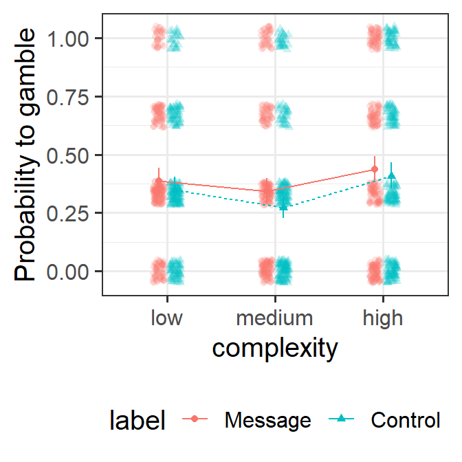

```r
afex_plot(mmin, "complexity", "label", dodge = 0.3,
          data_alpha = 0.2, mapping = c("linetype", "fill", "color", "shape"),
          factor_levels = list(label = c("Message", "Control")),
          data_arg = list(
            position =
              ggplot2::position_jitterdodge(
                jitter.width = 0.2,
                jitter.height = 0.05,
                dodge.width = 0.3  ## needs to be same as dodge
                ))) +
  ylab("Probability to gamble")
```

We also create a figure for the paper.

```
## Aggregating data over: newid
```

```
## NOTE: Results may be misleading due to involvement in interactions
```

```
## Renaming/reordering factor levels of 'label':
##   warning -> Message
##   control -> Control
```

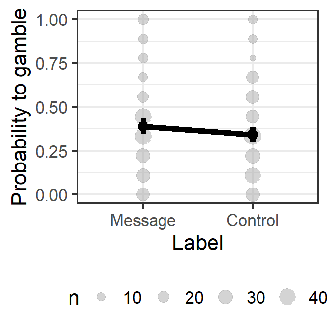

```r
theme_set(theme_bw(base_size = 16) +
            theme(legend.position="bottom"))

afex_plot(mmin, "label",
          mapping = c(""),
          data_geom = geom_count,
          data_arg = list(color = "darkgrey"),
          point_arg = list(size = 3.5),
          error_arg = list(size = 2, width = 0),
          factor_levels = list(label = c("Message", "Control"))) +
  ylab("Probability to gamble") + xlab("Label") +
  guides(shape = "none") +
  scale_size_area() +
  geom_line(aes(group = 1), size = 2)
```

```r
 ggsave("plot1.png", device = "png",
       width = 9, height = 9, units = "cm",
       dpi = 600)
```

## Effect Size

The effect size for binomial data is odds ratio (OR). Here, it is based on the best model.

```r
emmeans(mmin, c("label"), type = "response") %>%
  pairs %>%
  update(by = NULL) %>%
  summary(adjust = "holm", infer = TRUE)
```

```
## NOTE: Results may be misleading due to involvement in interactions
```

```
##  contrast          odds.ratio   SE  df asymp.LCL asymp.UCL null z.ratio p.value
##  warning / control       1.22 0.17 Inf     0.933      1.61    1   1.457  0.1450
##
## Results are averaged over the levels of: complexity
## Confidence level used: 0.95
## Conf-level adjustment: bonferroni method for 1 estimates
## Intervals are back-transformed from the log odds ratio scale
## P value adjustment: holm method for 1 tests
## Tests are performed on the log odds ratio scale
```

For reference, again the predicted marginal means of the model.

```r
emmeans(mmin, c("label"), type = "response")
```

```
## NOTE: Results may be misleading due to involvement in interactions
```

```
##  label    prob     SE  df asymp.LCL asymp.UCL
##  warning 0.388 0.0232 Inf     0.344     0.434
##  control 0.341 0.0222 Inf     0.299     0.386
##
## Results are averaged over the levels of: complexity
## Confidence level used: 0.95
## Intervals are back-transformed from the logit scale
```

# Exploratory Analysis

Following our preregistration, we also inspect whether the additional covariates affect the probability to gamble.

```r
dfull <- left_join(dl, add_vars, by = "newid")
## remove participant where gender is na
dfull2 <- dfull %>%
  filter(!is.na(gender)) %>%
  droplevels
covariates <- c("gender", "age_z", "freq_z", "psg_z")
```

```r
extra_main <- map(covariates, fit_combined_formula,
    formula_fixed = response ~ label*complexity,
    formula_random = "+ (1|newid)",
    data = dfull2, by = "+", cl = cl)
names(extra_main) <- covariates
extra_inter <- map(covariates, fit_combined_formula,
    formula_fixed = response ~ label*complexity,
    formula_random = "+ (1|newid)",
    data = dfull2, by = "*", cl = cl, all_fit = TRUE)
names(extra_inter) <- covariates
```

## Covariates added as main effects

```r
walk(extra_main, print)
```

```
## Mixed Model Anova Table (Type 3 tests, LRT-method)
##
## Model: response ~ label * complexity + gender + (1 | newid)
## Data: data
## Df full model: 8
##             Effect df     Chisq p.value
## 1            label  1      2.18    .140
## 2       complexity  2 34.06 ***   <.001
## 3           gender  1      2.22    .136
## 4 label:complexity  2      1.72    .423
## ---
## Signif. codes:  0 '***' 0.001 '**' 0.01 '*' 0.05 '+' 0.1 ' ' 1
## Mixed Model Anova Table (Type 3 tests, LRT-method)
##
## Model: response ~ label * complexity + age_z + (1 | newid)
## Data: data
## Df full model: 8
##             Effect df     Chisq p.value
## 1            label  1      1.91    .166
## 2       complexity  2 34.07 ***   <.001
## 3            age_z  1      0.64    .425
## 4 label:complexity  2      1.73    .422
## ---
## Signif. codes:  0 '***' 0.001 '**' 0.01 '*' 0.05 '+' 0.1 ' ' 1
## Mixed Model Anova Table (Type 3 tests, LRT-method)
##
## Model: response ~ label * complexity + freq_z + (1 | newid)
## Data: data
## Df full model: 8
##             Effect df     Chisq p.value
## 1            label  1      1.87    .171
## 2       complexity  2 34.05 ***   <.001
## 3           freq_z  1    3.31 +    .069
## 4 label:complexity  2      1.71    .425
## ---
## Signif. codes:  0 '***' 0.001 '**' 0.01 '*' 0.05 '+' 0.1 ' ' 1
## Mixed Model Anova Table (Type 3 tests, LRT-method)
##
## Model: response ~ label * complexity + psg_z + (1 | newid)
## Data: data
## Df full model: 8
##             Effect df     Chisq p.value
## 1            label  1      1.92    .165
## 2       complexity  2 34.06 ***   <.001
## 3            psg_z  1      0.23    .633
## 4 label:complexity  2      1.72    .423
## ---
## Signif. codes:  0 '***' 0.001 '**' 0.01 '*' 0.05 '+' 0.1 ' ' 1
```

When added as main effects, the additional covariates do not reveal additional significant effects.

## Covariates added as interactions

```r
walk(extra_inter, print)
```

```
## Mixed Model Anova Table (Type 3 tests, LRT-method)
##
## Model: response ~ label * complexity * gender + (1 | newid)
## Data: data
## Df full model: 13
##                    Effect df     Chisq p.value
## 1                   label  1      1.72    .190
## 2              complexity  2 32.34 ***   <.001
## 3                  gender  1      2.16    .141
## 4        label:complexity  2      1.56    .458
## 5            label:gender  1      0.07    .785
## 6       complexity:gender  2    5.08 +    .079
## 7 label:complexity:gender  2      1.41    .495
## ---
## Signif. codes:  0 '***' 0.001 '**' 0.01 '*' 0.05 '+' 0.1 ' ' 1
## Mixed Model Anova Table (Type 3 tests, LRT-method)
##
## Model: response ~ label * complexity * age_z + (1 | newid)
## Data: data
## Df full model: 13
##                   Effect df     Chisq p.value
## 1                  label  1      2.05    .152
## 2             complexity  2 33.33 ***   <.001
## 3                  age_z  1      0.74    .390
## 4       label:complexity  2      1.76    .415
## 5            label:age_z  1    4.53 *    .033
## 6       complexity:age_z  2      4.29    .117
## 7 label:complexity:age_z  2    6.39 *    .041
## ---
## Signif. codes:  0 '***' 0.001 '**' 0.01 '*' 0.05 '+' 0.1 ' ' 1
## Mixed Model Anova Table (Type 3 tests, LRT-method)
##
## Model: response ~ label * complexity * freq_z + (1 | newid)
## Data: data
## Df full model: 13
##                    Effect df     Chisq p.value
## 1                   label  1      1.90    .169
## 2              complexity  2 34.03 ***   <.001
## 3                  freq_z  1    3.57 +    .059
## 4        label:complexity  2      1.71    .426
## 5            label:freq_z  1      1.54    .215
## 6       complexity:freq_z  2    5.17 +    .075
## 7 label:complexity:freq_z  2      3.14    .208
## ---
## Signif. codes:  0 '***' 0.001 '**' 0.01 '*' 0.05 '+' 0.1 ' ' 1
```

```
## Mixed Model Anova Table (Type 3 tests, LRT-method)
##
## Model: response ~ label * complexity * psg_z + (1 | newid)
## Data: data
## Df full model: 13
##                   Effect df     Chisq p.value
## 1                  label  1      1.91    .167
## 2             complexity  2 33.96 ***   <.001
## 3                  psg_z  1      0.19    .659
## 4       label:complexity  2      1.72    .422
## 5            label:psg_z  1      0.00   >.999
## 6       complexity:psg_z  2      3.11    .211
## 7 label:complexity:psg_z  2      4.49    .106
## ---
## Signif. codes:  0 '***' 0.001 '**' 0.01 '*' 0.05 '+' 0.1 ' ' 1
```

Gender and frequency of gambling still do not show any significant effects. Furthermore, the model containing PSG, shows numerical problem suggesting that the results cannot be trusted. However, age interacts with label and with label and complexity. We will explore this effect in the following.

Before doing so, we fit another variant of the model for PSG. However, this time without complexity.

```r
extra_c <- fit_combined_formula(
  covariate = "psg_z",
  formula_fixed = response ~ label,
  formula_random = "+ (1|newid)",
  data = dfull2, by = "*", cl = cl, all_fit = TRUE)
```

```
## Contrasts set to contr.sum for the following variables: label, newid
```

```
## Numerical variables NOT centered on 0: psg_z
## If in interactions, interpretation of lower order (e.g., main) effects difficult.
```

```r
extra_c
```

```
## Mixed Model Anova Table (Type 3 tests, LRT-method)
##
## Model: response ~ label * psg_z + (1 | newid)
## Data: data
## Df full model: 5
##        Effect df Chisq p.value
## 1       label  1  1.86    .173
## 2       psg_z  1  0.23    .633
## 3 label:psg_z  1  0.00    .986
## ---
## Signif. codes:  0 '***' 0.001 '**' 0.01 '*' 0.05 '+' 0.1 ' ' 1
```

This model does not show any critical convergence problems, but still shows no interaction of PSG with label.

## Effect of Age

```r
emmeans(extra_inter[["age_z"]], c("label"), by = "age_z",
        type = "response", at = list(age_z = c(-1, 0, 1)),
        data = dfull2) %>%
  pairs %>%
  update(by = NULL) %>%
  summary(adjust = "holm")
```

```
## NOTE: Results may be misleading due to involvement in interactions
```

```
##  contrast          age_z odds.ratio    SE  df null z.ratio p.value
##  warning / control -1         0.906 0.176 Inf    1  -0.509  0.6110
##  warning / control 0          1.220 0.168 Inf    1   1.440  0.2999
##  warning / control 1          1.643 0.324 Inf    1   2.516  0.0356
##
## Results are averaged over the levels of: complexity
## P value adjustment: holm method for 3 tests
## Tests are performed on the log odds ratio scale
```

```r
emmeans(extra_inter[["age_z"]], c("label"), by = "age_z",
        type = "response", at = list(age_z = c(-1, 0, 1)),
        data = dfull2)
```

```
## NOTE: Results may be misleading due to involvement in interactions
```

```
## age_z = -1:
##  label    prob     SE  df asymp.LCL asymp.UCL
##  warning 0.367 0.0317 Inf     0.308     0.431
##  control 0.391 0.0330 Inf     0.328     0.457
##
## age_z =  0:
##  label    prob     SE  df asymp.LCL asymp.UCL
##  warning 0.388 0.0231 Inf     0.344     0.434
##  control 0.342 0.0222 Inf     0.300     0.387
##
## age_z =  1:
##  label    prob     SE  df asymp.LCL asymp.UCL
##  warning 0.410 0.0333 Inf     0.346     0.476
##  control 0.297 0.0296 Inf     0.242     0.358
##
## Results are averaged over the levels of: complexity
## Confidence level used: 0.95
## Intervals are back-transformed from the logit scale
```

```r
emmeans(extra_inter[["age_z"]], c("label"), by = c("complexity", "age_z"),
        type = "response", at = list(age_z = c(-1, 0, 1)),
        data = dfull2) %>%
  pairs %>%
  update(by = NULL) %>%
  summary(adjust = "holm")
```

```
##  contrast          complexity age_z odds.ratio    SE  df null z.ratio p.value
##  warning / control low        -1         1.109 0.264 Inf    1   0.436  1.0000
##  warning / control medium     -1         0.920 0.222 Inf    1  -0.347  1.0000
##  warning / control high       -1         0.728 0.172 Inf    1  -1.344  1.0000
##  warning / control low        0          1.159 0.196 Inf    1   0.873  1.0000
##  warning / control medium     0          1.393 0.239 Inf    1   1.930  0.3752
##  warning / control high       0          1.125 0.189 Inf    1   0.699  1.0000
##  warning / control low        1          1.210 0.292 Inf    1   0.793  1.0000
##  warning / control medium     1          2.109 0.522 Inf    1   3.015  0.0231
##  warning / control high       1          1.737 0.421 Inf    1   2.276  0.1830
##
## P value adjustment: holm method for 9 tests
## Tests are performed on the log odds ratio scale
```

We see that there seems to be an ironic effect of the warning labels for older participants (at mean age plus 1 SD), such that the warning **increases** the probability to gamble. The second analysis shows that this seems to hold only for medium complex gambles.

One possibility is that this finding does not represent a genuine effect but noise, potentially because there there are only few older participants. To check this, we look whether we can find a similar pattern, after binning the data. We use two binning approaches, approximately similar bin widths or bins with approximately the same number of participants.

```r
add_vars <- add_vars %>%
  mutate(age_bin3 = cut(age, 3, labels = c("low", "medium", "high")),
         age_bin2 = cut(age, 2, labels = c("low", "high")),
         age_bin_m2 = cut_number(age, 2, labels = c("low", "high")),
         age_bin_m3 = cut_number(age, 3, labels = c("low", "medium", "high")))
dfull2 <- left_join(dl, add_vars) %>%
  filter(!is.na(gender)) %>%
  droplevels
add_vars %>%
  group_by(age_bin2) %>%
  summarise(mean = mean(age),
            min = min(age),
            max = max(age),
            n = n())
```

```
## # A tibble: 2 x 5
##   age_bin2  mean   min   max     n
##   <fct>    <dbl> <dbl> <dbl> <int>
## 1 low       31.7    18    45   404
## 2 high      53.7    46    72   102
```

```r
add_vars %>%
  group_by(age_bin_m2) %>%
  summarise(mean = mean(age),
            min = min(age),
            max = max(age),
            n = n())
```

```
## # A tibble: 2 x 5
##   age_bin_m2  mean   min   max     n
##   <fct>      <dbl> <dbl> <dbl> <int>
## 1 low         27.5    18    34   263
## 2 high        45.4    35    72   243
```

```r
psych::describe(add_vars$age)
```

```
##    vars   n  mean    sd median trimmed   mad min max range skew kurtosis  se
## X1    1 506 36.12 11.15     34   35.24 10.38  18  72    54 0.68    -0.11 0.5
```

### Equally Sized Bins

We first look at the data split into two approximately equally sized bins (at the median, with the median age being assigned to the lower category).

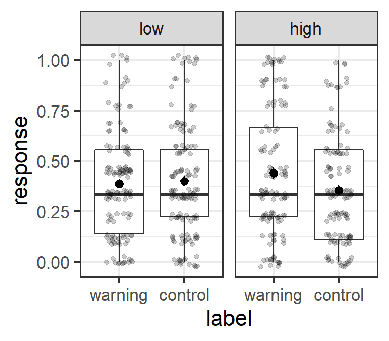

```r
add_vars %>%
  right_join(dl, by = "newid") %>%
  group_by(newid, age_bin_m2, label) %>%
  summarise(response = mean(response)) %>%
  ggplot(aes(x = label, y = response)) +
  geom_boxplot(outlier.color = "transparent") +
  geom_jitter(width = 0.2, height = 0.025, alpha = 0.2) +
  stat_summary(fun.data = mean_se) +
  facet_wrap("age_bin_m2")
```

```r
mextra_age_a <- fit_combined_formula(
  covariate = "age_bin_m2",
  formula_fixed = response ~ label*complexity,
  formula_random = "+ (1|newid)",
  data = dfull2, by = "*", cl = cl
)
nice(mextra_age_a)
```

```
## Mixed Model Anova Table (Type 3 tests, LRT-method)
##
## Model: response ~ label * complexity * age_bin_m2 + (1 | newid)
## Data: data
## Df full model: 13
##                        Effect df     Chisq p.value
## 1                       label  1      2.19    .139
## 2                  complexity  2 33.54 ***   <.001
## 3                  age_bin_m2  1      0.00   >.999
## 4            label:complexity  2      1.82    .402
## 5            label:age_bin_m2  1    4.19 *    .041
## 6       complexity:age_bin_m2  2      2.76    .252
## 7 label:complexity:age_bin_m2  2      4.30    .117
## ---
## Signif. codes:  0 '***' 0.001 '**' 0.01 '*' 0.05 '+' 0.1 ' ' 1
```

```r
emmeans(mextra_age_a, "label", by = "age_bin_m2", type = "response")
```

```
## NOTE: Results may be misleading due to involvement in interactions
```

```
## age_bin_m2 = low:
##  label    prob     SE  df asymp.LCL asymp.UCL
##  warning 0.356 0.0311 Inf     0.298     0.419
##  control 0.374 0.0316 Inf     0.315     0.438
##
## age_bin_m2 = high:
##  label    prob     SE  df asymp.LCL asymp.UCL
##  warning 0.423 0.0340 Inf     0.358     0.491
##  control 0.310 0.0307 Inf     0.253     0.373
##
## Results are averaged over the levels of: complexity
## Confidence level used: 0.95
## Intervals are back-transformed from the logit scale
```

```r
emmeans(mextra_age_a, "label", by = "age_bin_m2", type = "response") %>%
  pairs %>%
  update(by = NULL) %>%
  summary(adjust = "holm")
```

```
## NOTE: Results may be misleading due to involvement in interactions
```

```
##  contrast          age_bin_m2 odds.ratio    SE  df null z.ratio p.value
##  warning / control low             0.924 0.177 Inf    1  -0.411  0.6812
##  warning / control high            1.632 0.326 Inf    1   2.452  0.0284
##
## Results are averaged over the levels of: complexity
## P value adjustment: holm method for 2 tests
## Tests are performed on the log odds ratio scale
```

The graphical analysis as well as the statistical analysis suggest that there might be such an ironic effect of the warning label for older participants.

### Bins of Equal Width

We then inspect the data in the same way based on bins with equal width.

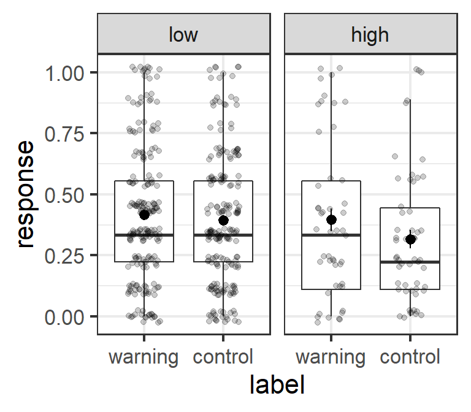

```r
add_vars %>%
  right_join(dl, by = "newid") %>%
  group_by(newid, age_bin2, label) %>%
  summarise(response = mean(response)) %>%
  ggplot(aes(x = label, y = response)) +
  geom_boxplot(outlier.color = "transparent") +
  geom_jitter(width = 0.2, height = 0.025, alpha = 0.2) +
  stat_summary(fun.data = mean_se) +
  facet_wrap("age_bin2")
```

```r
mextra_age_b <- fit_combined_formula(
  covariate = "age_bin2",
  formula_fixed = response ~ label*complexity,
  formula_random = "+ (1|newid)",
  data = dfull2, by = "*", cl = cl
)
nice(mextra_age_b)
```

```
## Mixed Model Anova Table (Type 3 tests, LRT-method)
##
## Model: response ~ label * complexity * age_bin2 + (1 | newid)
## Data: data
## Df full model: 13
##                      Effect df    Chisq p.value
## 1                     label  1     2.67    .102
## 2                complexity  2 10.45 **    .005
## 3                  age_bin2  1   2.93 +    .087
## 4          label:complexity  2     3.70    .157
## 5            label:age_bin2  1     0.90    .343
## 6       complexity:age_bin2  2   7.57 *    .023
## 7 label:complexity:age_bin2  2     3.46    .178
## ---
## Signif. codes:  0 '***' 0.001 '**' 0.01 '*' 0.05 '+' 0.1 ' ' 1
```

```r
emmeans(mextra_age_b, "label", by = "age_bin2", type = "response")
```

```
## age_bin2 = low:
##  label    prob     SE  df asymp.LCL asymp.UCL
##  warning 0.394 0.0257 Inf     0.345     0.445
##  control 0.366 0.0256 Inf     0.317     0.417
##
## age_bin2 = high:
##  label    prob     SE  df asymp.LCL asymp.UCL
##  warning 0.362 0.0523 Inf     0.267     0.469
##  control 0.265 0.0420 Inf     0.191     0.355
##
## Results are averaged over the levels of: complexity
## Confidence level used: 0.95
## Intervals are back-transformed from the logit scale
```

```r
emmeans(mextra_age_b, "label", by = "age_bin2", type = "response") %>%
  pairs %>%
  update(by = NULL) %>%
  summary(adjust = "holm")
```

```
##  contrast          age_bin2 odds.ratio    SE  df null z.ratio p.value
##  warning / control low            1.13 0.174 Inf    1   0.783  0.4338
##  warning / control high           1.57 0.491 Inf    1   1.448  0.2951
##
## Results are averaged over the levels of: complexity
## P value adjustment: holm method for 2 tests
## Tests are performed on the log odds ratio scale
```

Here, the interaction does not reach significance anymore. However, at least descriptively the pattern is still there.

In sum, there is some evidence that there exists an ironic effect of the warning label on older participants, but the evidence is weak. Replication is necessary to provide more conclusive evidence.

## All Covariates

As a final model, we try to run a model with all covariates. For computational reasons we only include the effect of label in addition to the effect of the four covariates.

```r
m_joint_1 <- mixed(response ~ label * (gender + age_z + freq_z + psg_z) +
                     (1|newid),
                   dfull2, method = "LRT", family = binomial,
                   progress = FALSE, cl = cl)
```

```
## Contrasts set to contr.sum for the following variables: label, gender, newid
```

```
## Numerical variables NOT centered on 0: age_z, freq_z, psg_z
## If in interactions, interpretation of lower order (e.g., main) effects difficult.
```

```r
m_joint_1
```

```
## Mixed Model Anova Table (Type 3 tests, LRT-method)
##
## Model: response ~ label * (gender + age_z + freq_z + psg_z) + (1 | newid)
## Data: dfull2
## Df full model: 11
##         Effect df  Chisq p.value
## 1        label  1   1.67    .196
## 2       gender  1   2.14    .144
## 3        age_z  1   0.31    .580
## 4       freq_z  1 3.24 +    .072
## 5        psg_z  1   1.40    .236
## 6 label:gender  1   0.10    .752
## 7  label:age_z  1 5.16 *    .023
## 8 label:freq_z  1 3.75 +    .053
## 9  label:psg_z  1   0.71    .399
## ---
## Signif. codes:  0 '***' 0.001 '**' 0.01 '*' 0.05 '+' 0.1 ' ' 1
```

This model shows the same effect of age as above.

```r
emmeans(m_joint_1, c("label"), by = "age_z",
        type = "response", at = list(age_z = c(-1, 0, 1)),
        data = dfull2) %>%
  pairs %>%
  update(by = NULL) %>%
  summary(adjust = "holm")
```

```
##  contrast          age_z odds.ratio    SE  df null z.ratio p.value
##  warning / control -1         0.875 0.174 Inf    1  -0.672  0.5018
##  warning / control 0          1.206 0.173 Inf    1   1.304  0.3847
##  warning / control 1          1.661 0.337 Inf    1   2.503  0.0370
##
## Results are averaged over the levels of: gender
## P value adjustment: holm method for 3 tests
## Tests are performed on the log odds ratio scale
```

```r
emmeans(m_joint_1, c("label"), by = "age_z",
        type = "response", at = list(age_z = c(-1, 0, 1)),
        data = dfull2)
```

```
## age_z = -1:
##  label    prob     SE  df asymp.LCL asymp.UCL
##  warning 0.368 0.0325 Inf     0.307     0.433
##  control 0.399 0.0339 Inf     0.335     0.467
##
## age_z =  0:
##  label    prob     SE  df asymp.LCL asymp.UCL
##  warning 0.397 0.0247 Inf     0.350     0.446
##  control 0.353 0.0228 Inf     0.310     0.399
##
## age_z =  1:
##  label    prob     SE  df asymp.LCL asymp.UCL
##  warning 0.427 0.0346 Inf     0.361     0.495
##  control 0.309 0.0311 Inf     0.252     0.373
##
## Results are averaged over the levels of: gender
## Confidence level used: 0.95
## Intervals are back-transformed from the logit scale
```

It also no suggests there might be an effect of frequency of gambling (`freq_z`). However, this effect does not reach significance (i.e., $p > .05$). When inspecting this effect, it suggests that if anything, the ironic effect of the warning label appears for participants with a low frequency of gambling.

```r
emmeans(m_joint_1, c("label"), by = "freq_z",
        type = "response", at = list(freq_z = c(-1, 0, 1)),
        data = dfull2) %>%
  pairs %>%
  update(by = NULL) %>%
  summary(adjust = "holm")
```

```
##  contrast          freq_z odds.ratio    SE  df null z.ratio p.value
##  warning / control -1          1.612 0.330 Inf    1   2.333  0.0590
##  warning / control 0           1.206 0.173 Inf    1   1.306  0.3832
##  warning / control 1           0.902 0.188 Inf    1  -0.493  0.6217
##
## Results are averaged over the levels of: gender
## P value adjustment: holm method for 3 tests
## Tests are performed on the log odds ratio scale
```

```r
emmeans(m_joint_1, c("label"), by = "freq_z",
        type = "response", at = list(freq_z = c(-1, 0, 1)),
        data = dfull2)
```

```
## freq_z = -1:
##  label    prob     SE  df asymp.LCL asymp.UCL
##  warning 0.466 0.0364 Inf     0.396     0.537
##  control 0.351 0.0326 Inf     0.290     0.417
##
## freq_z =  0:
##  label    prob     SE  df asymp.LCL asymp.UCL
##  warning 0.397 0.0247 Inf     0.350     0.446
##  control 0.353 0.0228 Inf     0.310     0.399
##
## freq_z =  1:
##  label    prob     SE  df asymp.LCL asymp.UCL
##  warning 0.332 0.0334 Inf     0.270     0.400
##  control 0.355 0.0331 Inf     0.293     0.422
##
## Results are averaged over the levels of: gender
## Confidence level used: 0.95
## Intervals are back-transformed from the logit scale
```

# Session Info

```r
options(width = 100)
```